# Team All Stars Lab 3

Johnny Tamanaha, Emily Archambault, Eugene Miller, Kaiyuan Fan, Jingzhi Zhang

9/13/2019

## Question: Does smoking affect health?

## Why is this question important?

This is an important question because if there was a correlation to poor health effects and smoking, this would have massive and widespread negative implications for anyone who smokes and the cigarette industry as a whole. Knowing that information is essential for consumers who might need to re-evaluate their decisions regarding smoking or seek additional healthcare, as well as for companies who are trying to sell this product, lawmakers who want to help protect people from dangerous risks associated with cigarettes, and the medical field who should understand the effects that smoking has on a patient’s wellbeing.

## Team Plot:

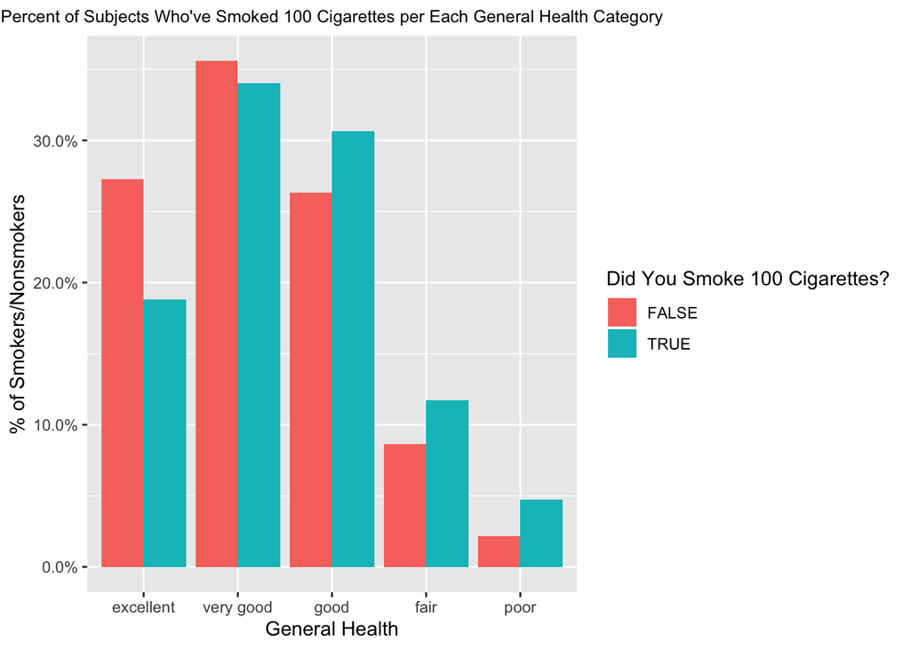

```r
ggplot(data = cdc, aes(group = smoke100)) +
  geom_bar(mapping=aes(x=genhlth, y = ..prop.., fill=smoke100==1), position="dodge") +
  scale_y_continuous(labels=scales::percent) +
  labs(x="General Health", y="% of Smokers/Nonsmokers", fill="Did You Smoke 100 Cigarettes?", title="Percent of Subjects Who've Smoked 100 Cigarettes per Each General Health Category") +
  theme(plot.title = element_text(hjust = 0.5, size = 9.5))
```

## Finding & Conclusion:

From the team plot, we can see the percentage of nonsmoker is higher than the percentage of smoker in excellent and very good general health status. And in the good, fair and poor health status, the percentage of smoker is clearly higher than the nonsmoker.However there is no distinct difference between the percentages of smokers and nonsmokers under very good General Health. In conclusion, smoking do have harmful affect to health.

## Recommendation for Action:

Therefore, we conclude that smoking does harm to the health of people already. Obviously, Smoking cessation is necessary. However, as we all know, It is hard to quit nicotine addiction. Here are some recommendations for people who still smoke. Firstly, Social organization should promote the effects of smoking, benefits of cessation for their lung condition and treatment options. On the other hand, personal awareness of the health risks of tobacco was considered a necessary early intervention to dissuade people from starting and continuing to smoke.

## Individual Sections:

### Eugene Miller

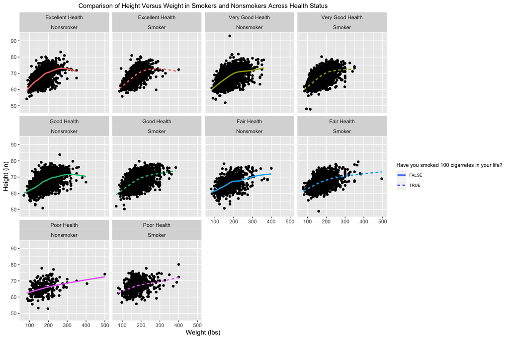

```r
health.labs <- c("Excellent Health", "Very Good Health", "Good Health", "Fair Health", "Poor Health")
names(health.labs) <- c("excellent", "very good", "good", "fair", "poor")
smoke.labs <- c("Nonsmoker", "Smoker")
names(smoke.labs) <- c("0", "1")

ggplot(data = cdc, mapping = aes(x = weight, y = height)) +
  geom_jitter() +
  geom_smooth(mapping = aes(color = genhlth, linetype = smoke100==1), se = FALSE) +
  labs(title = "Comparison of Height Versus Weight in Smokers and Nonsmokers Across Health Status", y = "Height (in)", x = "Weight (lbs)", linetype = "Have you smoked 100 cigarretes in your life?") +
  guides(color = FALSE) +
  theme(plot.title = element_text(hjust = 0.5, size = 10.8), legend.title = element_text(size = 9), legend.text = element_text(size = 7)) +
  facet_wrap(genhlth~smoke100, labeller = labeller(smoke100 = smoke.labs, genhlth = health.labs))
```

**Explanation of Findings:** There are no major differences between smokers and nonsmokers in terms of height versus weight correlations even when accounting for health status. This suggests that health status plays a larger role in determining the ratio of one’s height versus weight rather than whether or not an individual is a smoker. This would seem to make sense, as to whether or not an individual smokes may not be the largest factor impacting their health. For example, a nonsmoker with a serious illness is likely to not have the same weight to height ratio as a smoker who otherwise is in perfect health.

### Johnny Tamanaha

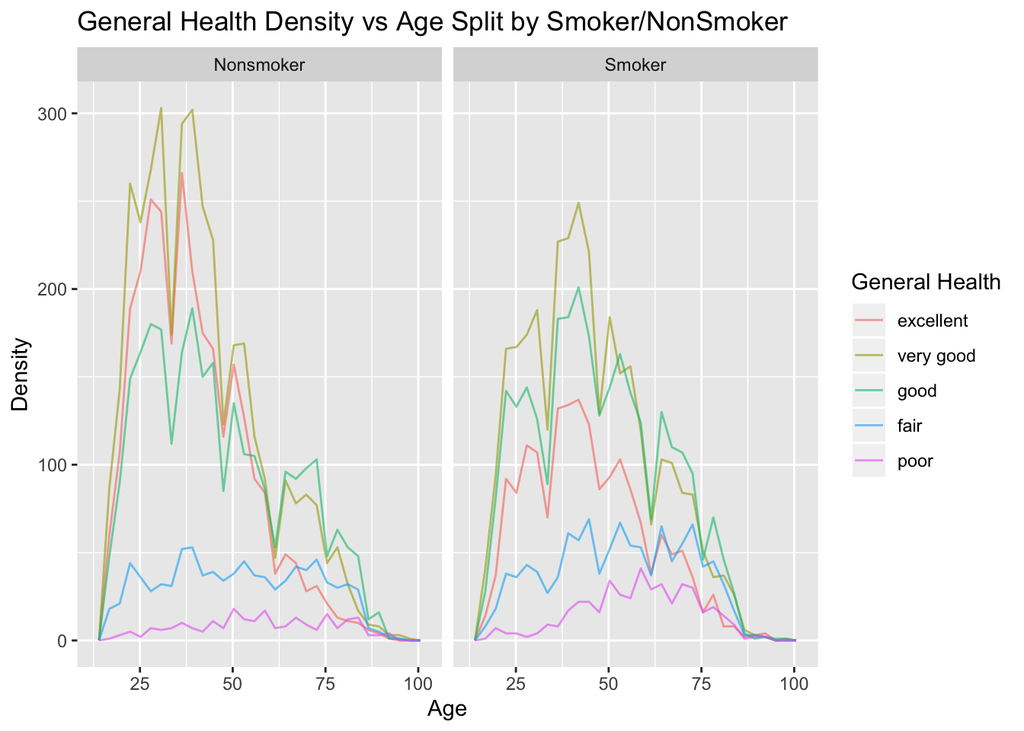

```r
smoke.labs <- c("Nonsmoker", "Smoker")
names(smoke.labs) <- c("0", "1")
ggplot(cdc) +
  geom_freqpoly(mapping=aes(x=age, color=genhlth), alpha=.6, bins=30) +
  facet_wrap(~smoke100, labeller = labeller(smoke100 = smoke.labs)) +
  labs(x="Age", y="Density", color="General Health", title="General Health Density vs Age Split by Smoker/NonSmoker")
```

**Explination of Findings:** Smokers seem more likely to have poor health at a older age while non-smokers seem to be more likely to have excellent/very good health at a younger age. Besides that there seems to be no significant difference between the groups.

### Kaiyuan Fan

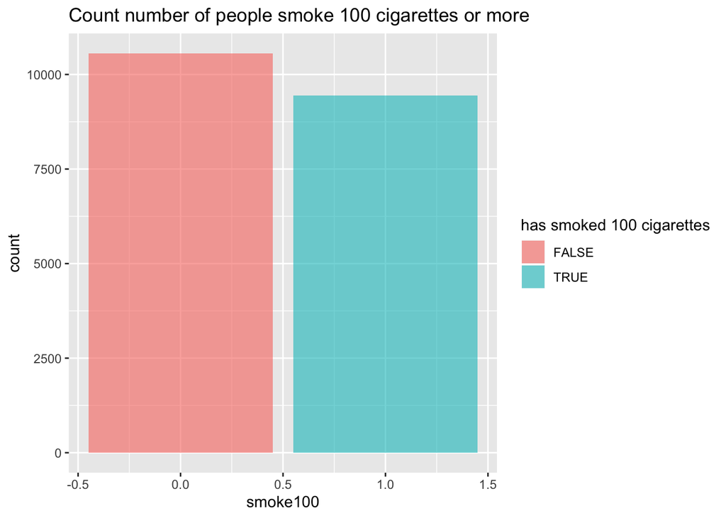

```r
ggplot(cdc, aes(x = smoke100))+
 geom_bar(aes(fill = smoke100 == 1),alpha = 3/5, position = "identity", show.legend = TRUE) +
 labs(x= "smoke100", y="count", fill = "has smoked 100 cigarettes", title = "Count number of people smoke 100 cigarettes or more")
```

**Explanation of Findings:** My plot is to count the number of people who smokes and who does smoke. If people smoke 100 cigarettes or more through life, then the smoke100 equals 1, which is green color on the plot. And if people doesn’t smoke or smoke less than 100 cigarettes, the smoke100 equals 0, which is red showing on the plot. I find people who do not smoke are more than people smoke.

### Jingzhi Zhang

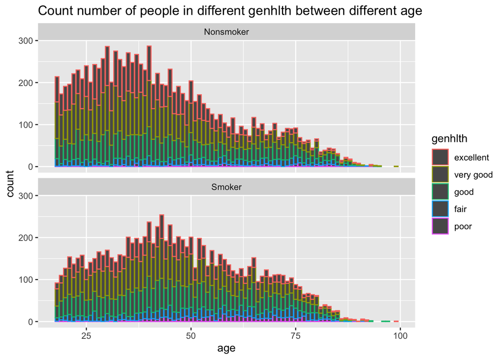

```r
smoke.labs <- c("Nonsmoker", "Smoker")
names(smoke.labs) <- c("0", "1")
ggplot(data = cdc, mapping = aes(x = age, color = genhlth)) +
  geom_bar()+
  facet_wrap(~ smoke100,labeller = labeller(smoke100 = smoke.labs), nrow = 2)+
labs(x= "age", y="count", fill = "genhlth", title = "Count number of people in different genhlth between different age")
```

### Emily Archambault

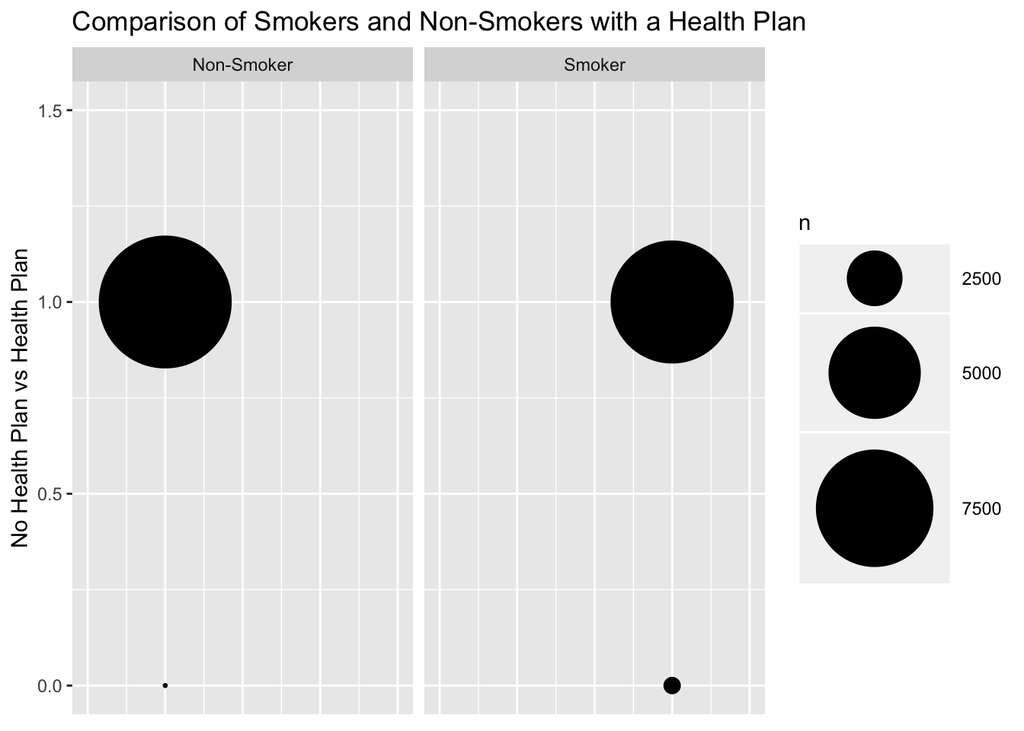

```r
smoke.labs <- c("Non-Smoker", "Smoker")
names(smoke.labs) <- c("0", "1")
ggplot(data = cdc) +
geom_count(mapping = aes(x = smoke100, y = hlthplan)) +
facet_grid (.~smoke100, labeller = labeller(smoke100 = smoke.labs)) +
coord_cartesian(xlim=c(-0.5,1.5), ylim=c(0,1.5)) +
scale_size_continuous(range = c(0.5, 30)) +
theme(axis.title.x=element_blank(), axis.text.x=element_blank(), axis.ticks.x=element_blank()) + labs(title = "Comparison of Smokers and Non-Smokers with a Health Plan", y = "No Health Plan vs Health Plan")
```

**Explanation of Findings:** My graph shows the comparison between the relative number of smokers and non-smokers who have or do not have health plans. It seems that, between those health plans, there are a higher number of non-smokers, and for those without health plans, there are a higher number of smokers.

## Individual Contributions

### Emily Archambault

I made a graph showing how the number of people with a health care plan compares between smokers and non-smokers. The data showed that a greater number of people with health care plans were non-smokers, and the greater number of people without health care plans were smokers. I used the geom_count geom function and facet_grid to make the contrast easier to see. I also changed the default labels so it was easier to interpret, the coord function to expand the graph and make the points more visible, and scaled the size of the points so it was easier to compare them. I used a theme to get rid of the x-axis markings, and finally added other labels and a title. I also wrote the section explaining the importance of our question.

### Eugene Miller

I graphed the correlation between height and weight between smokers and non-smokers across different health groups. The data showed no visually discernible difference between the smoking and nonsmoking groups. I used geom_jitter and facet_wrap across two variable to demonstrate this and highlighted each health group with colour coded geom_smooth functions. I also made some formatting and font changes to make the plot appear nicer and easier to read. I changed the labels for both the health group and smoking variables. I helped come up with our guiding research question, and also did formatting work on the team plot as well.

### Johnny Tamanaha

I graphed the correlation between age and general health, faceted on if the subject smoked 100 cigarettes or not. The data showed that for older people there was a higher density of people with poor health that smoked. Also, for younger people there was a higher density of people with excellent health that didn’t smoke. I used the freqpoly geom function and changed the color to make the curves pop out more. I also lowered the alpha to make overlapping lines more distinct. I changed the default labels to make the plot easier to read. I also created the team plot that showed how the proportions of smokers/nonsmokers changed per each general health category. This graph showed higher proportions of non-smokers in better health categories.

### Kaiyuan Fan

I made a graph is to count the number of people who smoke 100 cigarettes in their life and I find that people who do not smoke is more than people who smoke. In the team plot part, I give the recommendation of action in future based on our facts and conclusion.